# Predictive- Neural Net

Shyni David

5/13/2019

### Introduction

WOSU’s primary source of funding comes from individual community support. With over 27,000 donors providing annual support equaling approximately $4 million with additional major and planned gift support, the development team seeks to develop a deeper understanding of our constituency. Currently, the development teams work out of multiple databases and static documents with a treasure trove of disparate data about our donors. From an analytics needs assessment, WOSU is at the base level of analytics and need to lay the foundation in order to further utilize our data for targeted fundraising approaches, but also to eventually build toward predictive modelling of future WOSU donors.

—-In the winter of 2018, in our kick off meeting with WOSU team, Rob Walker said quote unquote “We do not know who our donors are. We would like to know who they are.”

### Objective

WOSU’s primary source of funding comes from individual community support. Their development team is seeking to develop a deeper understanding of the constituencies by using data analytics in understanding the past and projecting the future. When donors approach philanthropy, their gifts are thoughtful and has intended purposes and seek a return on their philanthropic investments.  
A pertinent question is why do they give to WOSU? WOSU has a wide variety of fundraising programs through events, radio, TV , web, emails and personal contact. Which of these tasks contribute to increased giving? Which tasks detract from the fundraising success? What is the spread of the donors across the country? What should the campaign goal be? What are the factors for their success?  
The exploratory data analysis will be used to investigate the trends. The statistical tools and techniques will help to interpret the data and build models to increase the predictability, thus empowering WOSU to strategically invest their resources in increasing the scalability and sustainability of donations.

### Dataset

There are 3 Datasets provided by WOSU:  
1. 2000-2009 – 33740 observations (represents Original Donations), 22 variables/attributes  
2. 2010-2018- 36361 observations(represents Original Donations), 22variables/attributes  
3. Event files – 22 Text file corresponding to some events since 2014 with the names and date and other related information.

##### Importing the necessary libraries

```r
#install.packages("MASS")
library(MASS)
#install.packages("tidyverse")
library(tidyverse)
#install.packages("sqldf")
library(sqldf)
#install.packages("lubridate")
library(lubridate)
#install.packages("dplyr")
library(dplyr)
#install.packages("plyr")
library(plyr)
#install.packages("readxl")
library(readxl)
#install.packages("ggplot2")
library(ggplot2)
library(scales)
library(stringr)
#install.packages("USAboundaries")
library(USAboundaries)
#install.packages("gender")
library(gender)
#install.packages("caret")
library(caret)
 library(glmnet)
library(gridExtra)
#install.packages("VIM")
library(VIM)
library(lubridate)
library(grid)
#install.packages("XML")
library(XML)
#install.packages("httr")
library("httr")
#install.packages("VIM")
library(VIM)
#install.packages("car")
library(car)
#install.packages("rpart.plot")
library(rpart.plot)
library(caretEnsemble) # for Stacking
#install.packages("doParallel")
library(doParallel)  # parallel processing
#install.packages("nnet")
library(nnet) # for multinomial logit

library(ggplot2)
library(scales)

load("~/Desktop/FISHER SMB-A/capstone/SMB-A Capstone Project/0504 files pre process.RData")
```

Prepare file for Model

```r
  x  <- Final_file_kNN %>%  select(Gift_Month, Gift_Year, gender, Original_Gift_Source, Solicitation_Method,  Original_Gift_Amount, Solicitation_Type ,Original_Gift_Mode, Orig_Gift_Has_Prm, City, Account_Status, State, Region, Division)


#add dummy variables for Original Gift Source
y_01 <- x %>% mutate(GS_radio = ifelse(Original_Gift_Source == "radio", 1, 0))
y_02 <- y_01 %>% mutate(GS_acquisition = ifelse(Original_Gift_Source == "acquisition", 1, 0))
y_03 <- y_02 %>% mutate(GS_mail = ifelse(Original_Gift_Source == "mail", 1, 0))
y_04 <- y_03 %>% mutate(GS_otwhite = ifelse(Original_Gift_Source == "otwhite", 1, 0))
y_05 <- y_04 %>% mutate(GS_specialopportunity = ifelse(Original_Gift_Source == "special opportunity", 1, 0))
y_06 <- y_05 %>% mutate(GS_yearend = ifelse(Original_Gift_Source == "yearend", 1, 0))
y_07 <- y_06 %>% mutate(GS_newyear = ifelse(Original_Gift_Source == "newyear", 1, 0))
y_08 <- y_07 %>% mutate(GS_showcase = ifelse(Original_Gift_Source == "showcase", 1, 0))
y_09 <- y_08 %>% mutate(GS_passport = ifelse(Original_Gift_Source == "passport", 1, 0))
y_10 <- y_09 %>% mutate(GS_annfund = ifelse(Original_Gift_Source == "annual fund", 1, 0))
y_11 <- y_10 %>% mutate(GS_tv = ifelse(Original_Gift_Source == "tv", 1, 0))
y_12 <- y_11 %>% mutate(GS_web = ifelse(Original_Gift_Source == "web", 1, 0))


# add dummy variables for Solicitation method
y_13 <- y_12  %>%  mutate(SM_onair = ifelse(Solicitation_Method == "On Air", 1, 0))
y_14 <- y_13 %>%  mutate(SM_autoren = ifelse(Solicitation_Method == "Auto Renewal", 1, 0))
y_15 <- y_14 %>%  mutate(SM_other = ifelse(Solicitation_Method == "Other", 1, 0))
 y_16 <- y_15 %>%  mutate(SM_web = ifelse(Solicitation_Method == "Web", 1, 0))
y_17 <- y_16 %>%  mutate(SM_directmail = ifelse(Solicitation_Method == "Direct Mail", 1, 0))
y_18 <- y_17 %>%  mutate(SM_email = ifelse(Solicitation_Method == "Email", 1, 0))
y_19 <- y_18 %>%  mutate(SM_perscont = ifelse(Solicitation_Method == "Personal Contact", 1, 0))
y_20 <- y_19 %>%  mutate(SM_online = ifelse(Solicitation_Method == "Online", 1, 0))
y_21 <- y_20 %>%  mutate(SM_telemkt = ifelse(Solicitation_Method == "Telemarketing", 1, 0))

y_22 <- y_21 %>%  mutate(ST_acq = ifelse(Solicitation_Type == "Acquisition", 1, 0))
y_23 <- y_22 %>%  mutate(ST_ren = ifelse(Solicitation_Type == "Renewal", 1, 0))
y_24 <- y_23 %>%  mutate(ST_othr = ifelse(Solicitation_Type == "Other", 1, 0))
y_25 <- y_24 %>%  mutate(ST_exp = ifelse(Solicitation_Type == "Expired", 1, 0))
y_26 <- y_25 %>%  mutate(ST_addgift = ifelse(Solicitation_Type == "Additional Gift", 1, 0))

y_27 <- y_26 %>% mutate(GS_cba = ifelse(Original_Gift_Source == "cba", 1, 0))
y_28 <- y_27 %>% mutate(GS_oa = ifelse(Original_Gift_Source == "openask", 1, 0))

y_final<- y_28


sapply(y_final , function(x) sum(is.na(x)))
```

```
##            Gift_Month             Gift_Year                gender
##                     0                     0                     0
##  Original_Gift_Source   Solicitation_Method  Original_Gift_Amount
##                     0                     0                     0
##     Solicitation_Type    Original_Gift_Mode     Orig_Gift_Has_Prm
##                     0                     0                     0
##                  City        Account_Status                 State
##                     0                     0                     0
##                Region              Division              GS_radio
##                     0                     0                     0
##        GS_acquisition               GS_mail            GS_otwhite
##                     0                     0                     0
## GS_specialopportunity            GS_yearend            GS_newyear
##                     0                     0                     0
##           GS_showcase           GS_passport            GS_annfund
##                     0                     0                     0
##                 GS_tv                GS_web              SM_onair
##                     0                     0                     0
##            SM_autoren              SM_other                SM_web
##                     0                     0                     0
##         SM_directmail              SM_email           SM_perscont
##                     0                     0                     0
##             SM_online            SM_telemkt                ST_acq
##                     0                     0                     0
##                ST_ren               ST_othr                ST_exp
##                     0                     0                     0
##            ST_addgift                GS_cba                 GS_oa
##                     0                     0                     0
```

```r
y_final$gender <- as.factor(y_final$gender)
y_final$Account_Status <- as.factor(y_final$Account_Status)
y_final$Orig_Gift_Has_Prm <- as.factor(y_final$Orig_Gift_Has_Prm)
y_final$City <- as.factor(y_final$City)
y_final_01 <- y_final %>% mutate(logDonation = log(Original_Gift_Amount))

y_final_02 <- y_final_01 %>% select(-4,-5,-6,-7)
```

Prepare Models- US - individuals

```r
# test run model

model_01x <- lm(logDonation ~ Gift_Month + Gift_Year + gender + GS_radio + GS_acquisition + GS_mail + GS_otwhite + GS_specialopportunity + GS_showcase + GS_passport + GS_annfund  + GS_web   + GS_mail + GS_cba + GS_oa  + SM_autoren + SM_other   + SM_email   + SM_online    + SM_telemkt  + ST_ren  + ST_exp  + Orig_Gift_Has_Prm + Account_Status + Original_Gift_Mode, data = y_final_02)

summary(model_01x)
```

```
##
## Call:
## lm(formula = logDonation ~ Gift_Month + Gift_Year + gender +
##     GS_radio + GS_acquisition + GS_mail + GS_otwhite + GS_specialopportunity +
##     GS_showcase + GS_passport + GS_annfund + GS_web + GS_mail +
##     GS_cba + GS_oa + SM_autoren + SM_other + SM_email + SM_online +
##     SM_telemkt + ST_ren + ST_exp + Orig_Gift_Has_Prm + Account_Status +
##     Original_Gift_Mode, data = y_final_02)
##
## Residuals:
##     Min      1Q  Median      3Q     Max
## -4.8964 -0.3525  0.0140  0.3703  5.4226
##
## Coefficients:
##                                             Estimate Std. Error  t value
## (Intercept)                               -7.0081733  1.0712519   -6.542
## Gift_Month                                 0.0000987  0.0006606    0.149
## Gift_Year                                  0.0059648  0.0005332   11.186
## gendermale                                 0.0603948  0.0046827   12.897
## GS_radio                                  -0.1902180  0.0057965  -32.816
## GS_acquisition                            -0.3226847  0.0121805  -26.492
## GS_mail                                   -0.2911717  0.0461618   -6.308
## GS_otwhite                                -0.0975134  0.0203799   -4.785
## GS_specialopportunity                     -0.0435735  0.0166084   -2.624
## GS_showcase                                0.1197746  0.0350977    3.413
## GS_passport                               -0.0451882  0.0142576   -3.169
## GS_annfund                                -1.3652135  0.0573203  -23.817
## GS_web                                    -0.1020502  0.0142248   -7.174
## GS_cba                                    -0.2988349  0.0393956   -7.585
## GS_oa                                     -0.7270538  0.0161091  -45.133
## SM_autoren                                 0.6925066  0.0974290    7.108
## SM_other                                   0.5490116  0.0377572   14.541
## SM_email                                   0.2564596  0.0562901    4.556
## SM_online                                 -0.0640010  0.4313298   -0.148
## SM_telemkt                                -0.1675603  0.2317950   -0.723
## ST_ren                                    -0.0743424  0.0707914   -1.050
## ST_exp                                    -0.0658655  0.0881914   -0.747
## Orig_Gift_Has_PrmN                        -0.9802744  0.0066957 -146.404
## Account_StatusActive                       0.1398983  0.0062951   22.223
## Account_StatusContributor                 -0.4175091  0.0152534  -27.372
```

[output cut: 29 more lines]

```
## Orig_Gift_Has_PrmN                         < 2e-16 ***
## Account_StatusActive                       < 2e-16 ***
## Account_StatusContributor                  < 2e-16 ***
## Original_Gift_ModeOne time cash            < 2e-16 ***
## Original_Gift_ModeMonthly Credit Card     0.037784 *
## Original_Gift_ModeEFT Monthly             7.76e-06 ***
## Original_Gift_ModeQuarterly Credit Card   0.083557 .
## Original_Gift_ModeEFT one time            0.695549
## Original_Gift_ModeSemi Annual Credit Card 0.063245 .
## ---
## Signif. codes:  0 '***' 0.001 '**' 0.01 '*' 0.05 '.' 0.1 ' ' 1
##
## Residual standard error: 0.6098 on 69947 degrees of freedom
## Multiple R-squared:  0.4861, Adjusted R-squared:  0.4859
## F-statistic:  2206 on 30 and 69947 DF,  p-value: < 2.2e-16
```

```r
vif(model_01x)
```

```
##                           GVIF Df GVIF^(1/(2*Df))
## Gift_Month            1.038470  1        1.019054
## Gift_Year             1.659271  1        1.288127
## gender                1.008058  1        1.004021
## GS_radio              1.564377  1        1.250751
## GS_acquisition        2.416272  1        1.554436
## GS_mail               2.562134  1        1.600667
## GS_otwhite            1.125930  1        1.061098
## GS_specialopportunity 1.331119  1        1.153741
## GS_showcase           1.022389  1        1.011132
## GS_passport           1.461366  1        1.208870
## GS_annfund            1.770882  1        1.330745
## GS_web                1.189039  1        1.090431
## GS_cba                1.076989  1        1.037781
## GS_oa                 1.638215  1        1.279928
## SM_autoren            2.141707  1        1.463457
## SM_other              1.888072  1        1.374071
## SM_email              2.207225  1        1.485673
## SM_online             1.000605  1        1.000303
## SM_telemkt            1.011321  1        1.005644
## ST_ren                2.419585  1        1.555502
## ST_exp                1.024167  1        1.012012
## Orig_Gift_Has_Prm     1.977437  1        1.406214
## Account_Status        1.410822  2        1.089853
## Original_Gift_Mode    2.977344  6        1.095181
```

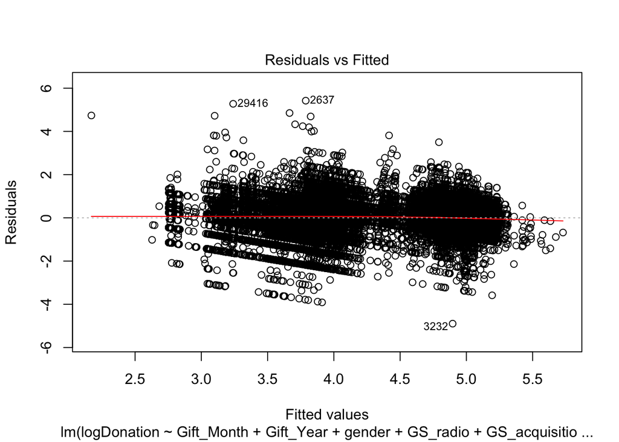

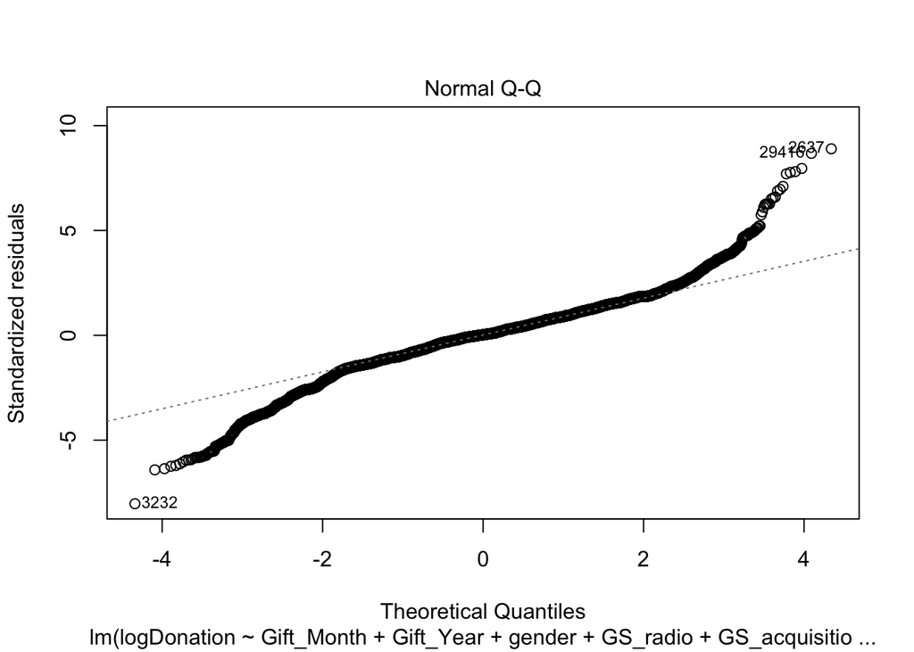

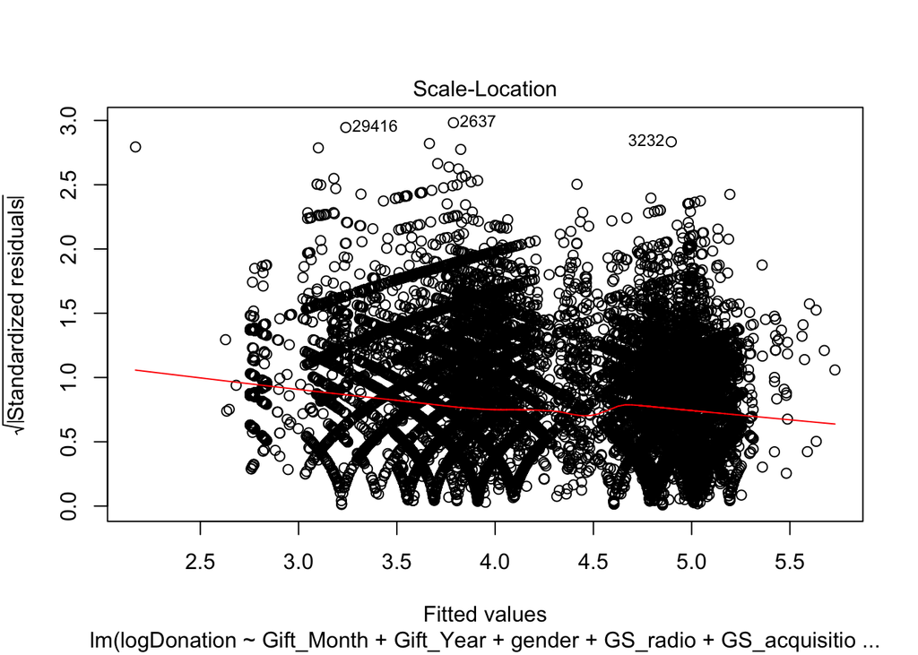

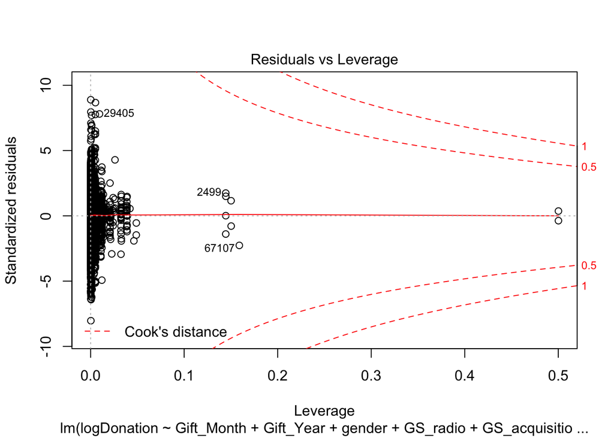

```r
plot(model_01x)
```

```r
model_02x <- lm(logDonation ~ Gift_Month + Gift_Year + gender + GS_radio + GS_acquisition + GS_mail + GS_otwhite + GS_specialopportunity + GS_showcase + GS_passport + GS_annfund  + GS_web   + GS_mail + GS_cba + GS_oa    + Orig_Gift_Has_Prm + Account_Status + Original_Gift_Mode + Region + Division , data = y_final_02)

summary(model_02x)
```

```
##
## Call:
## lm(formula = logDonation ~ Gift_Month + Gift_Year + gender +
##     GS_radio + GS_acquisition + GS_mail + GS_otwhite + GS_specialopportunity +
##     GS_showcase + GS_passport + GS_annfund + GS_web + GS_mail +
##     GS_cba + GS_oa + Orig_Gift_Has_Prm + Account_Status + Original_Gift_Mode +
##     Region + Division, data = y_final_02)
##
## Residuals:
##     Min      1Q  Median      3Q     Max
## -4.9407 -0.3528  0.0147  0.3673  5.3554
##
## Coefficients:
##                                             Estimate Std. Error  t value
## (Intercept)                               -7.6532597  1.0728337   -7.134
## Gift_Month                                 0.0008196  0.0006596    1.243
## Gift_Year                                  0.0062828  0.0005339   11.767
## gendermale                                 0.0609452  0.0046927   12.987
## GS_radio                                  -0.1891122  0.0058099  -32.550
## GS_acquisition                            -0.3343540  0.0121428  -27.535
## GS_mail                                   -0.1760636  0.0295616   -5.956
## GS_otwhite                                -0.0926373  0.0204222   -4.536
## GS_specialopportunity                      0.0180622  0.0159034    1.136
## GS_showcase                                0.1240330  0.0351745    3.526
## GS_passport                               -0.0502266  0.0142747   -3.519
## GS_annfund                                -0.8326176  0.0442739  -18.806
## GS_web                                    -0.1059161  0.0142524   -7.431
## GS_cba                                    -0.3090147  0.0394436   -7.834
## GS_oa                                     -0.7400077  0.0160999  -45.963
## Orig_Gift_Has_PrmN                        -0.9771796  0.0066979 -145.894
## Account_StatusActive                       0.1408611  0.0063357   22.233
## Account_StatusContributor                 -0.4188914  0.0152926  -27.392
## Original_Gift_ModeOne time cash           -0.1154920  0.0082632  -13.977
## Original_Gift_ModeMonthly Credit Card     -0.0142820  0.0083721   -1.706
## Original_Gift_ModeEFT Monthly              0.0885633  0.0186883    4.739
## Original_Gift_ModeQuarterly Credit Card   -0.1014617  0.0641772   -1.581
## Original_Gift_ModeEFT one time             0.0448810  0.1099116    0.408
## Original_Gift_ModeSemi Annual Credit Card -0.1623976  0.1199225   -1.354
## Region                                    -0.0141584  0.0103206   -1.372
## Division                                   0.0133030  0.0033150    4.013
```

[output cut: 18 more lines]

```
## Account_StatusContributor                  < 2e-16 ***
## Original_Gift_ModeOne time cash            < 2e-16 ***
## Original_Gift_ModeMonthly Credit Card     0.088030 .
## Original_Gift_ModeEFT Monthly             2.15e-06 ***
## Original_Gift_ModeQuarterly Credit Card   0.113891
## Original_Gift_ModeEFT one time            0.683027
## Original_Gift_ModeSemi Annual Credit Card 0.175681
## Region                                    0.170114
## Division                                  6.00e-05 ***
## ---
## Signif. codes:  0 '***' 0.001 '**' 0.01 '*' 0.05 '.' 0.1 ' ' 1
##
## Residual standard error: 0.6111 on 69952 degrees of freedom
## Multiple R-squared:  0.4838, Adjusted R-squared:  0.4837
## F-statistic:  2623 on 25 and 69952 DF,  p-value: < 2.2e-16
```

```r
vif(model_02x)
```

```
##                           GVIF Df GVIF^(1/(2*Df))
## Gift_Month            1.031008  1        1.015386
## Gift_Year             1.656316  1        1.286979
## gender                1.007925  1        1.003955
## GS_radio              1.564695  1        1.250878
## GS_acquisition        2.390836  1        1.546233
## GS_mail               1.046139  1        1.022810
## GS_otwhite            1.125663  1        1.060973
## GS_specialopportunity 1.215166  1        1.102346
## GS_showcase           1.022379  1        1.011128
## GS_passport           1.458467  1        1.207670
## GS_annfund            1.051879  1        1.025612
## GS_web                1.188438  1        1.090155
## GS_cba                1.074893  1        1.036770
## GS_oa                 1.629190  1        1.276397
## Orig_Gift_Has_Prm     1.970092  1        1.403600
## Account_Status        1.422845  2        1.092168
## Original_Gift_Mode    2.865592  6        1.091695
## Region                1.298819  1        1.139657
## Division              1.311109  1        1.145037
```

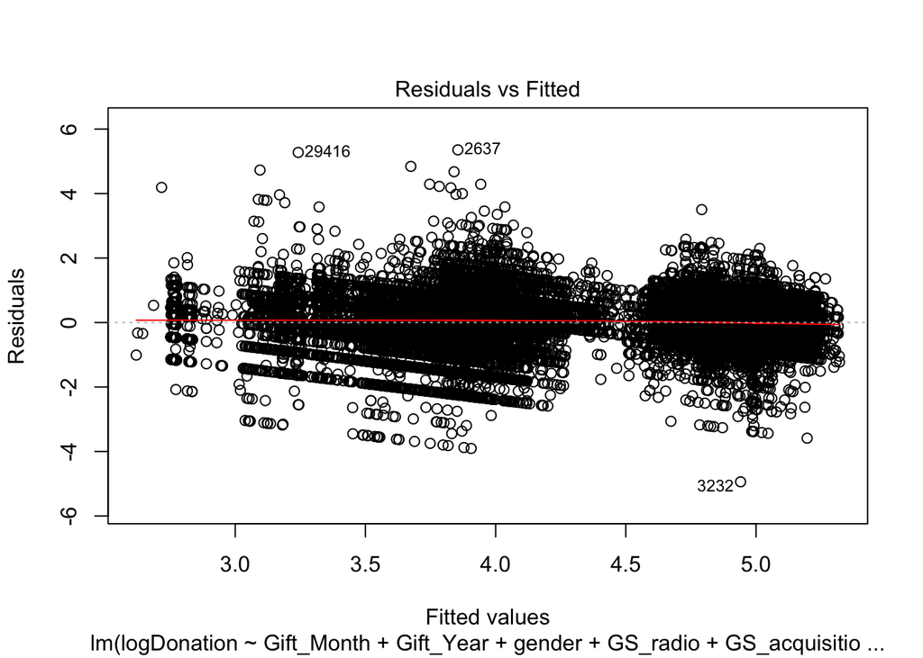

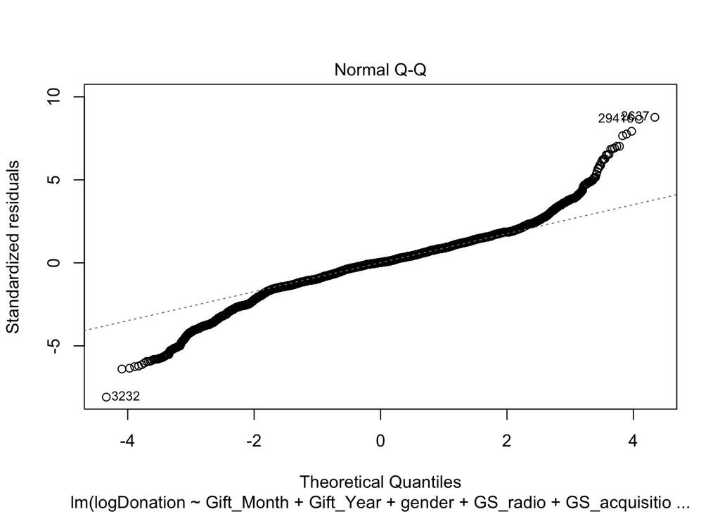

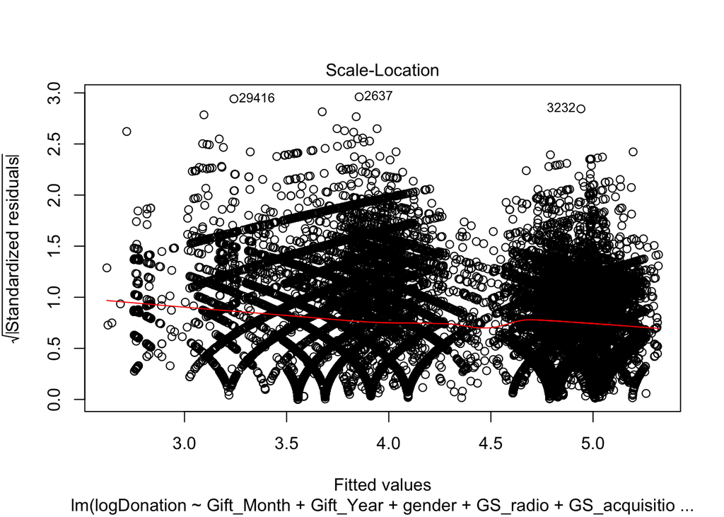

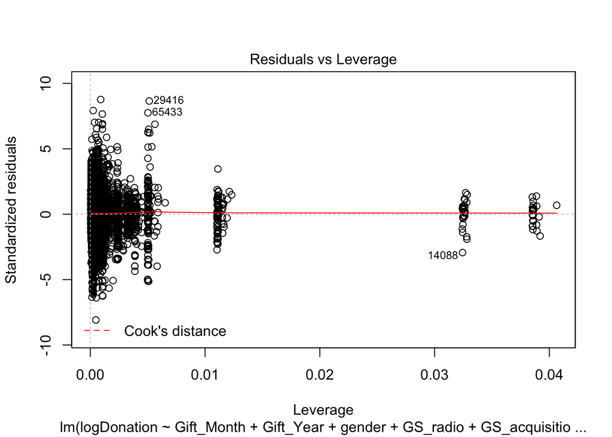

```r
plot(model_02x)
```

**Set up for parallel processing**

```r
numberofcores = detectCores() # get the number of cores (to create a cluster)
cl <- makeCluster(numberofcores-1) # make a cluster; allocating all but one core
registerDoParallel(cl)
```

Train and Test Model- Individuals File

```r
set.seed(1234)
training.samples <- y_final_02$logDonation %>%
  createDataPartition(p = 0.75, list = FALSE)
train.data  <- y_final_02[training.samples, ]
test.data <- y_final_02[-training.samples, ]
```

# 3. Neural Network

# If in some cross-validation folds the predictions get zero variance, the model didn’t converge. #In such cases, you can try the neuralnet package which offers two parameters you can tune:

# 1. threshold : default value = 0.01. Set it to 0.3 and then try lower values 0.2, 0.1, 0.05.

# 2. stepmax : default value = 1e+05. Set it to 1e+08 and then try lower values 1e+07, 1e+06.

```r
set.seed(1234)

neural1 <- train(logDonation  ~ Gift_Month + Gift_Year + gender + GS_radio + GS_acquisition + GS_mail + GS_otwhite + GS_specialopportunity + GS_showcase + GS_passport + GS_annfund  + GS_web   + GS_mail + GS_cba + GS_oa  + SM_autoren + SM_other   + SM_email   + SM_online    + SM_telemkt +  + ST_ren  + ST_exp  + Orig_Gift_Has_Prm + Account_Status + Original_Gift_Mode, data = train.data, method="nnet",
                 preProcess = "range",  linout=TRUE, trace=FALSE, threshold =  0.3,
                 trControl = trainControl("cv", number = 10), tuneLength = 10) # tuneLength
print(neural1)
```

```
## Neural Network
##
## 52485 samples
##    24 predictor
##
## Pre-processing: re-scaling to [0, 1] (30)
## Resampling: Cross-Validated (10 fold)
## Summary of sample sizes: 47235, 47237, 47237, 47237, 47236, 47237, ...
## Resampling results across tuning parameters:
##
##   size  decay         RMSE       Rsquared   MAE
##    1    0.0000000000  0.6912291  0.3662385  0.5217913
##    1    0.0001000000  0.6470507  0.4623225  0.4854110
##    1    0.0002371374  0.6687290  0.3740063  0.5051930
##    1    0.0005623413  0.7143687  0.3500286  0.5433415
```

[output cut: 99 more lines]

```r
set.seed(1234)
neural2 <- train(logDonation  ~ Gift_Month + Gift_Year + gender + GS_radio + GS_acquisition + GS_mail + GS_otwhite + GS_specialopportunity + GS_showcase + GS_passport + GS_annfund  + GS_web   + GS_mail + GS_cba + GS_oa    + Orig_Gift_Has_Prm + Account_Status + Original_Gift_Mode + Region + Division, data = train.data, method="nnet",
                 preProcess = "range",  linout=TRUE, trace=FALSE, threshold =  0.3,
                 trControl = trainControl("cv", number = 10), tuneLength = 10) # tuneLength
print(neural2)
```

```
## Neural Network
##
## 52485 samples
##    19 predictor
##
## Pre-processing: re-scaling to [0, 1] (25)
## Resampling: Cross-Validated (10 fold)
## Summary of sample sizes: 47235, 47237, 47237, 47237, 47236, 47237, ...
## Resampling results across tuning parameters:
##
##   size  decay         RMSE       Rsquared   MAE
##    1    0.0000000000  0.7240063  0.3745537  0.5492732
##    1    0.0001000000  0.6909343  0.3302137  0.5240243
##    1    0.0002371374  0.6663658  0.3768521  0.4989294
##    1    0.0005623413  0.7007336  0.3445733  0.5321972
```

[output cut: 99 more lines]

```r
#plot relative feature importance
#garson(neural1$finalModel) + theme(axis.text.x = element_text(size =7,angle = 45, hjust = #1),axis.title.x=element_blank())

#plot relative feature importance
#garson(neural2$finalModel) + theme(axis.text.x = element_text(size =7,angle = 45, hjust = #1),axis.title.x=element_blank())


# Make predictions on test data
predictneural1 <- predict(neural1, newdata=test.data)
# Model performance - RMSE and Rsquare
pneural1 <- data.frame(RMSE = RMSE(predictneural1, test.data$logDonation), Rsquare = R2(predictneural1, test.data$logDonation))
pneural1
```

```
##        RMSE   Rsquare
## 1 0.5917185 0.5128965
```

```r
# Make predictions on test data
predictneural2 <- predict(neural2, newdata=test.data)
# Model performance - RMSE and Rsquare
pneural2 <- data.frame(RMSE = RMSE(predictneural2, test.data$logDonation), Rsquare = R2(predictneural2, test.data$logDonation))
pneural2
```

```
##        RMSE   Rsquare
## 1 0.6007675 0.4976933
```

**Stop parallel processing**

```r
stopCluster(cl) #shut down the cluster
registerDoSEQ() #switch back to sequential execution
```